# One Hidden Layer Neural Network

CS 640 Programming assignment 1  
Abhishek Rai Sharma Mohit Mohit  
March 6 2019

## Problem Definition

We have to build a neural network using one hidden layer. After that we have to train our model using given datasets and fine tune learning rate. Moreover, we have to implement L2 Regularization over the given neural network. Finally, we have to use the final output to recognize the hand-written digits.

## Implementation

We will implement a simple 2 layer neural network using the provided Logistic Regression template with following specification. Layer 1 :  
Input will be Number of features  
Output will be Number of nodes in hidden layer.  
Activation function used is Sigmoid

Layer 2 :  
Input will be number of nodes in hidden layer  
Output will be number of dimensions in the output = number of classes in y  
The ouput will be passed through softmax function.

# Code

## Imports

```python
import numpy as np
from one_layer_nn import one_layer_nn
import matplotlib.pyplot as plt
import one_layer_nn
import regularized_nn
from sklearn.model_selection import train_test_split
from sklearn.model_selection import KFold
from sklearn.metrics import confusion_matrix
from sklearn.metrics import classification_report
```

## One Layer Neural network code

```python
# sigmoid function
def sig(h):
    sig_h = np.exp(h)/(1+np.exp(h))
    return sig_h;

#softmax function
def softmax(z):
    exp_out = np.exp(z)
    softmax_scores = exp_out / np.sum(exp_out, axis=1, keepdims=True)
    return softmax_scores

def softmax_y(softmax_scores):
    return np.argmax(softmax_scores, axis=1)

class one_layer_nn():

    #weights Initialization
    def __init__(self,in_dim, nodes, out_dim, alpha=0.5 ):
        self.alpha=alpha
        self.w_hidden = np.random.randn(in_dim, nodes) / np.sqrt(in_dim)
        self.b_hidden = np.zeros((1, nodes))
        self.w_out = np.random.randn(nodes, out_dim)/np.sqrt(nodes)
        self.b_out = np.zeros((1, out_dim))

    #Calculates the activations in different layer
    def forward_prop(self,X_train):
        #input for hidden layer h
        in_h = np.dot(X_train, self.w_hidden) + self.b_hidden
        #passing through sigmoid function
        o_h = sig(in_h)
        #input to last layer z
        in_out = np.dot(o_h, self.w_out) + self.b_out
        #passing through softmax dunction
        o_out = softmax(in_out)
        activation = {"o_h": o_h , "o_out":o_out}
        return activation


    #Calculate the gradient wrt to theta and bias terms
    def back_prop(self,activation,X_train, y_train,m):
        #dummy type
        one_hot_y = np.zeros_like(activation["o_out"])
        for i in range(y_train.shape[0]):
            one_hot_y[i, y_train[i]] = 1


        o_out = activation["o_out"]
        #d(Performace) / d(net_out)
        dp_net_out = o_out - one_hot_y
        beta_out = dp_net_out
        o_h = activation["o_h"]

        #net_out = (o_h * w_out) + b_out
        #d(performance)/d(net_out) * d(net_out)/d(w_out)
        dp_w_out = np.dot(o_h.T, beta_out)/m
        #d(performance)/d(net_out) * d(net_out)/d(b_out)
        dp_b_out = np.sum(beta_out, axis=0, keepdims=True)/m # dp/dp_net_out  * dp_net_out/db


        #d(performance)/d(o_h) = d(performance) / d(net_out) *  d(net_out) / d(o_h)
        dp_o_h = np.dot(beta_out, self.w_out.T)

        #net_h = (X * w_h) + b_h
        #d(o_h)/d(net_h)
        doh_net_h = np.multiply(o_h, 1 - o_h)
        #d(performance)/d(net_h) = d(performance) / d(o_h) * d(o_h) /d(net_h) = dp_o_h * doh_net_h
        dp_net_h = np.multiply(dp_o_h, doh_net_h)
        #Calcuation for weight update in hidden layer
        beta_h = dp_net_h

        #d(performance)/d(net_h) * d(net_h)/d(w_h)
        dp_w_h = np.dot(X_train.T, beta_h)/m
        #d(performance)/d(net_h) * d(net_h)/d(b_h)
        dp_b_h = np.sum(beta_h, axis=0, keepdims=True)/m

        #Return updated gradients
        grad_des = {"w_out" : dp_w_out ,
                  "b_out" : dp_b_out ,
                  "w_h": dp_w_h ,
                  "b_h": dp_b_h}
        return grad_des

    def compute_cost(self,o_out,y,m):
        return  np.sum(1-(o_out == y))/m

    def update_weights (self, grad_des):
        self.b_hidden -= self.alpha*grad_des["b_h"]
        self.b_out -= self.alpha*grad_des["b_out"]
        self.w_hidden -= self.alpha*grad_des["w_h"]
        self.w_out -= self.alpha*grad_des["w_out"]

    def fit(self, X_train,y_train, num_epochs):
        train_error = []
        for i in range(num_epochs):
            activation = self.forward_prop( X_train)
            grad_des  = self.back_prop( activation,X_train, y_train,X_train.shape[0])
            self.update_weights(grad_des)
            if(i%10 == 0):
                #output of last layer(z)
                z_out = softmax_y(activation["o_out"])
                train_error += [self.compute_cost(z_out, np.array(y_train).T, X_train.shape[0])]
        return train_error

    def predict(self, X_test):
        output = self.forward_prop(X_test)
        o_out = output["o_out"]
        return softmax_y(o_out)
```

## Additional Method

```python
#decison boundary
def plot_decision_boundary(model, X, y,i):
    x1_array, x2_array = np.meshgrid(np.arange(-10, 10, 0.01), np.arange(-10, 10, 0.01))
    grid_coordinates = np.c_[x1_array.ravel(), x2_array.ravel()]
    Z = nn.predict(grid_coordinates)
    Z = Z.reshape(x1_array.shape)
    plt.contourf(x1_array, x2_array, Z, cmap=plt.cm.bwr)
    plt.scatter(X[:, 0], X[:, 1], c=y, cmap=plt.cm.bwr)
    plt.title('decison boundary for fold '+str(i))
    plt.show()
#K round robin
def k_fold(X,y,k,nn):
    kf = KFold(n_splits=k, random_state=None, shuffle=False)
    kf.get_n_splits(X)
    test_error = []
    train_error = []
    i=1
    for train_index, test_index in kf.split(X):
         X_train, X_test = X[train_index], X[test_index]
         y_train, y_test = y[train_index], y[test_index]
         train_error = (nn.fit(X_train, y_train, num_epochs = 2500))
         y_pred = nn.predict(X_test)
         test_error=(nn.compute_cost(y_pred, y_test, X.shape[0]))
         plt.plot(train_error)
         plt.title('Train Error for fold '+str(i))
         i+=1
         plt.xlabel('No. of epochs')
         plt.ylabel("Error")
         plt.show()
         print("Error rate: - "+str(test_error)+"\n")
         print("Confusion Matrix:-\n "+str(confusion_matrix(y_test, y_pred))+"\n")
         print("Classification Report:-\n"+str(classification_report(y_test,y_pred)))
         plot_decision_boundary(nn, X_train, y_train,i)
    return (np.sum(test_error)/(k+1))
```

# The cross validation procedure enables you to combine the results of five experiments. Why is this useful?

if we are in a situation of underfitted or overfitted. That is because how well our model is performing on the dataset we used to train our model, but we will be unsure about its performance on unseen dataset. hence,  
by using K Fold cross validation, we will devide the data into 5 parts and iterate for chossing each part for testing one by one, and by taking the average we will find the effectiveness of our model. As we use the most of our data for fitting, we significantly reduce bias of our network. Therefore, we can say that interchanging the training and testing dataset improves the effectiveness of our system.

## Linear Data with 5 Fold Round Robin

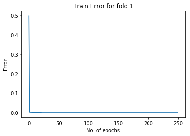

```
Error rate: - 0.0005

Confusion Matrix:-
 [[202   1]
 [  0 197]]

Classification Report:-
             precision    recall  f1-score   support

          0       1.00      1.00      1.00       203
          1       0.99      1.00      1.00       197

avg / total       1.00      1.00      1.00       400
```

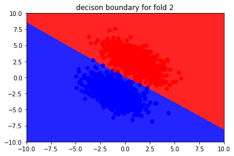

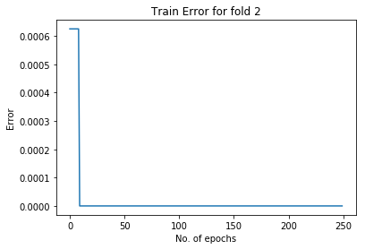

```
Error rate: - 0.0005

Confusion Matrix:-
 [[198   0]
 [  1 201]]

Classification Report:-
             precision    recall  f1-score   support

          0       0.99      1.00      1.00       198
          1       1.00      1.00      1.00       202

avg / total       1.00      1.00      1.00       400
```

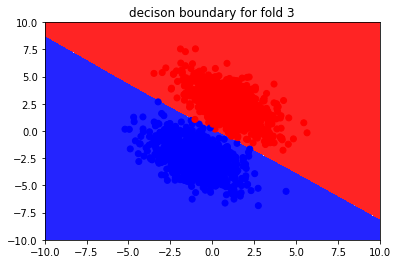

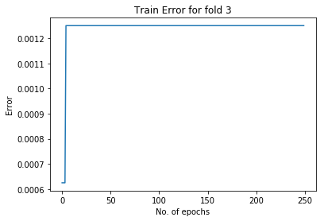

```
Error rate: - 0.0

Confusion Matrix:-
 [[205   0]
 [  0 195]]

Classification Report:-
             precision    recall  f1-score   support

          0       1.00      1.00      1.00       205
          1       1.00      1.00      1.00       195

avg / total       1.00      1.00      1.00       400
```

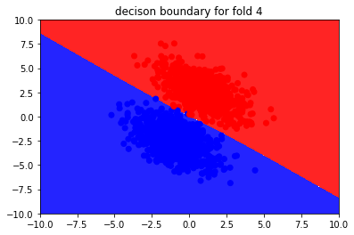

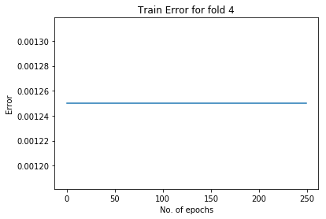

```
Error rate: - 0.0

Confusion Matrix:-
 [[192   0]
 [  0 208]]

Classification Report:-
             precision    recall  f1-score   support

          0       1.00      1.00      1.00       192
          1       1.00      1.00      1.00       208

avg / total       1.00      1.00      1.00       400
```

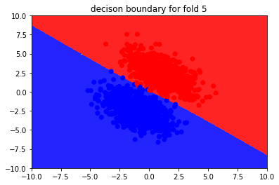

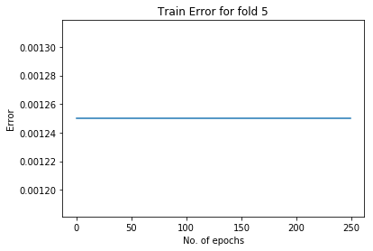

```
Error rate: - 0.0

Confusion Matrix:-
 [[202   0]
 [  0 198]]

Classification Report:-
             precision    recall  f1-score   support

          0       1.00      1.00      1.00       202
          1       1.00      1.00      1.00       198

avg / total       1.00      1.00      1.00       400
```

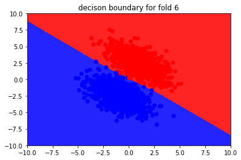

```
Average test error is : 0.0
```

```python
X_l = np.genfromtxt('DATA/data_linearX.csv', delimiter=',')
y_l = np.genfromtxt('DATA/data_linearY.csv', delimiter=',').astype(np.int64)
input_dim = int(X_l.shape[1])
output_dim = int(y_l.max() + 1)
nodes = 20
nn = one_layer_nn(input_dim,  nodes , output_dim)
test_error = k_fold(X_l,y_l,5,nn)
print("Average test error is :" , test_error)
```

## Non Linear Data with 5 Fold Round Robin

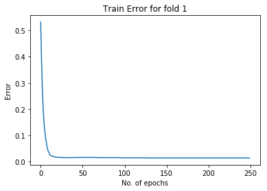

```
Error rate: - 0.003

Confusion Matrix:-
 [[197   2]
 [  4 197]]

Classification Report:-
             precision    recall  f1-score   support

          0       0.98      0.99      0.98       199
          1       0.99      0.98      0.98       201

avg / total       0.99      0.98      0.98       400
```

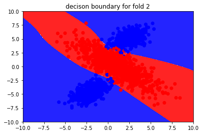

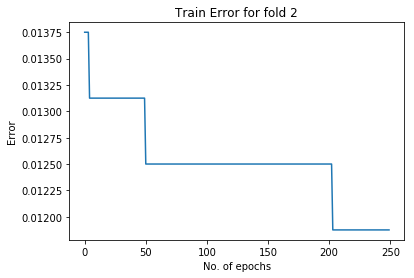

```
Error rate: - 0.0025

Confusion Matrix:-
 [[185   4]
 [  1 210]]

Classification Report:-
             precision    recall  f1-score   support

          0       0.99      0.98      0.99       189
          1       0.98      1.00      0.99       211

avg / total       0.99      0.99      0.99       400
```

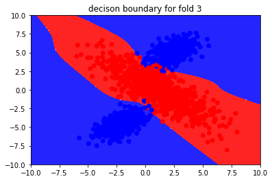

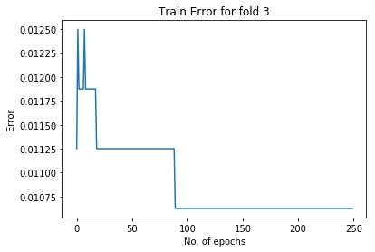

```
Error rate: - 0.0035

Confusion Matrix:-
 [[194   5]
 [  2 199]]

Classification Report:-
             precision    recall  f1-score   support

          0       0.99      0.97      0.98       199
          1       0.98      0.99      0.98       201

avg / total       0.98      0.98      0.98       400
```

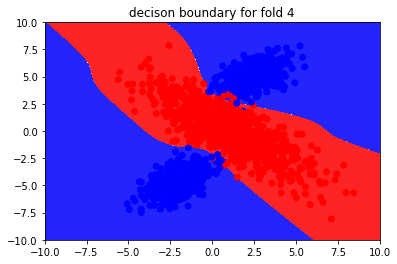

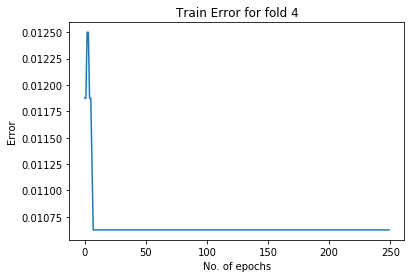

```
Error rate: - 0.002

Confusion Matrix:-
 [[217   0]
 [  4 179]]

Classification Report:-
             precision    recall  f1-score   support

          0       0.98      1.00      0.99       217
          1       1.00      0.98      0.99       183

avg / total       0.99      0.99      0.99       400
```

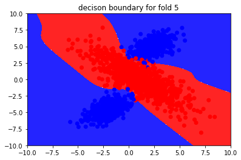

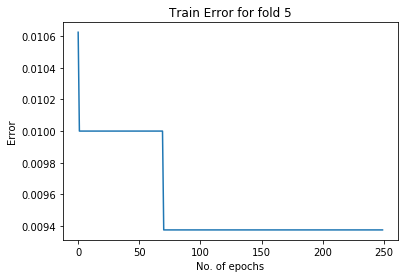

```
Error rate: - 0.0015

Confusion Matrix:-
 [[195   1]
 [  2 202]]

Classification Report:-
             precision    recall  f1-score   support

          0       0.99      0.99      0.99       196
          1       1.00      0.99      0.99       204

avg / total       0.99      0.99      0.99       400
```

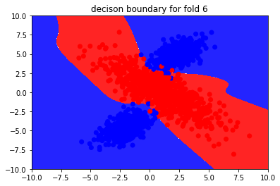

```
Average test error is : 0.00025
```

```python
X_nl = np.genfromtxt('DATA/data_nonLinearX.csv', delimiter=',')
y_nl = np.genfromtxt('DATA/data_nonLinearY.csv', delimiter=',').astype(np.int64)
input_dim = int(X_nl.shape[1])
output_dim = int(y_nl.max() + 1)
nodes = 20
nn = one_layer_nn(input_dim,  nodes , output_dim)
test_error =k_fold(X_nl,y_nl,5,nn)
print("Average test error is :" , test_error)
```

## Digit data

```
Error Rate:- 0.061247216035634745
Confusion Matrix:-
 [[85  0  0  0  1  0  2  0  0  0]
 [ 0 80  0  1  0  0  0  0  2  8]
 [ 0  0 84  2  0  0  0  0  0  0]
 [ 0  1  2 78  0  5  0  2  3  0]
 [ 0  1  0  0 87  0  1  0  0  3]
 [ 0  0  0  0  0 87  1  0  0  3]
 [ 0  1  0  0  0  0 90  0  0  0]
 [ 0  0  0  0  1  0  0 85  0  3]
 [ 0  5  0  1  0  3  0  0 79  0]
 [ 0  0  0  1  0  2  0  0  0 89]]

Classification Report:-
             precision    recall  f1-score   support

          0       1.00      0.97      0.98        88
          1       0.91      0.88      0.89        91
          2       0.98      0.98      0.98        86
          3       0.94      0.86      0.90        91
          4       0.98      0.95      0.96        92
          5       0.90      0.96      0.93        91
          6       0.96      0.99      0.97        91
          7       0.98      0.96      0.97        89
          8       0.94      0.90      0.92        88
          9       0.84      0.97      0.90        92

avg / total       0.94      0.94      0.94       899
```

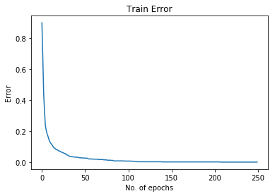

```python
X = np.genfromtxt('DATA/Digit_X_train.csv', delimiter=',')
y = np.genfromtxt('DATA/Digit_y_train.csv', delimiter=',').astype(np.int64)
m = X.shape[0]
input_dim = int(X.shape[1])
output_dim = int(y.max() + 1)
nodes = 20
nn=one_layer_nn(input_dim,  nodes , output_dim)
train_err = nn.fit(X,y,2500)
X_test = np.genfromtxt('DATA/Digit_X_test.csv', delimiter=',')
y_test = np.genfromtxt('DATA/Digit_y_test.csv', delimiter=',').astype(np.int64)

y_pred = nn.predict(X_test)

error_rate = nn.compute_cost(y_pred,y_test,m)
print("Error Rate:- "+str(error_rate))
print("Confusion Matrix:-\n "+str(confusion_matrix(y_test, y_pred))+"\n")
print("Classification Report:-\n"+str(classification_report(y_test,y_pred)))
plt.title('Train Error')
plt.xlabel('No. of epochs')
plt.ylabel("Error")
plt.plot(train_err)
plt.show()
```

# What is overfitting and why does it occur in practice? Name and briefly explain 3 ways to reduce overfitting.

If a model try to learn each and every detail then it may not perform well for the unseen data, is called overfitting. It occurs because the model attempts to pick up the noises in the training data and learn them as a concept, that's why it does not perform well for unseen data.

1. L2 regularization: It will increase the bias and expected error will be decreased.
2. Wrapper: We can use wrapper to enumerate the model with respect to the number of nodes in the neural network. Thus, we will have list of models with respective errors and we can chose the model with minimum error.
3. Feature selection: If the number of data points are less than the number of independent attributes. Thus, by discarding irrelevant attributes we can avoid overfitting.

## L2 Regularized Neural Network

```python
#!/usr/bin/env python3
# -*- coding: utf-8 -*-
"""
Created on Wed Feb 27 15:38:43 2019

@author: mohitbeniwal
"""

class regularized_nn(one_layer_nn):

    def __init__(self,input_dim, nodes, output_dim , alpha = 0.1,reg_para=0.001):
        self.alpha = alpha
        self.reg = reg_para
        super().__init__(input_dim, nodes, output_dim,alpha )

    def update_weight (self, grad_des):
        #Adding derivative of regularization term
        self.b_hidden -= self.reg*self.b_hidden
        self.b_out -= self.reg*self.b_out
        self.w_hidden-= self.reg*self.w_hidden
        self.w_out-= self.reg*self.w_out

        self.b_hidden -= self.alpha*grad_des["b_h"]
        self.b_out -= self.alpha*grad_des["b_out"]
        self.w_hidden -= self.alpha*grad_des["w_h"]
        self.w_out -= self.alpha*grad_des["w_out"]
```

## Digit data with L2 Regularized Model

```
Error Rate:- 0.09131403118040089

Confusion Matrix:-
 [[81  0  0  0  1  1  5  0  0  0]
 [ 0 75  0  1  2  0  2  0  0 11]
 [ 0  0 77  9  0  0  0  0  0  0]
 [ 0  0  3 80  0  2  0  4  1  1]
 [ 0  2  0  0 87  0  1  0  1  1]
 [ 0  0  0  0  0 86  1  0  0  4]
 [ 0  2  0  0  0  0 89  0  0  0]
 [ 0  0  0  0  1  0  0 87  1  0]
 [ 1  4  5  0  0  2  0  0 70  6]
 [ 0  0  0  5  0  2  0  0  0 85]]

Classification Report:-
             precision    recall  f1-score   support

          0       0.99      0.92      0.95        88
          1       0.90      0.82      0.86        91
          2       0.91      0.90      0.90        86
          3       0.84      0.88      0.86        91
          4       0.96      0.95      0.95        92
          5       0.92      0.95      0.93        91
          6       0.91      0.98      0.94        91
          7       0.96      0.98      0.97        89
          8       0.96      0.80      0.87        88
          9       0.79      0.92      0.85        92

avg / total       0.91      0.91      0.91       899
```

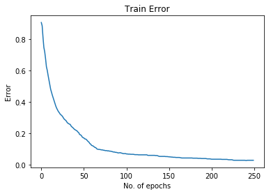

```python
X = np.genfromtxt('DATA/Digit_X_train.csv', delimiter=',')
y = np.genfromtxt('DATA/Digit_y_train.csv', delimiter=',').astype(np.int64)
m = X.shape[0]
input_dim = int(X.shape[1])
output_dim = int(y.max() + 1)
nodes = 20
nn=regularized_nn(input_dim,  nodes , output_dim)
train_err = nn.fit(X,y,2500)
X_test = np.genfromtxt('DATA/Digit_X_test.csv', delimiter=',')
y_test = np.genfromtxt('DATA/Digit_y_test.csv', delimiter=',').astype(np.int64)

y_pred = nn.predict(X_test)

error_rate = nn.compute_cost(y_pred,y_test,m)
print("Error Rate:- "+str(error_rate)+"\n")
print("Confusion Matrix:-\n "+str(confusion_matrix(y_test, y_pred))+"\n")
print("Classification Report:-\n"+str(classification_report(y_test,y_pred)))
plt.title('Train Error')
plt.xlabel('No. of epochs')
plt.ylabel("Error")
plt.plot(train_err)
plt.show()
```

## One common technique used to reduce overfitting is L2 regularization. How does L2 regularization prevent overfitting? How differently does your model perform before and after implementing L2 regularization?

To prevent overfitting by L2 regularization, we introduce a cost term for bringing in more features with the objective function. Which means we will penalize the hypothesis complexity. Therefore, it tries to push the coefficients for many variables to zero and hence reduce cost term.

# What effect does the learning rate have on how your neural network is trained?

learning rate will define the rate at which we are going to converge. Hence, a very low learning rate will take forever to converge. and if we will take larger learning rate then it way miss the local minima. Hence, if we chose an optimal learning rate, we would spend lesser time to train our neural network.

## Experements with Learning Rate on digits data

```
Learning Rate: -0.001
Error Rate:- 0.8151447661469933
```

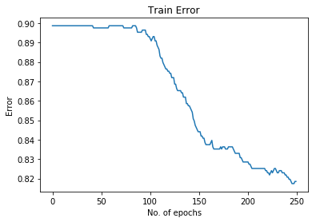

```
Learning Rate: -0.01
Error Rate:- 0.33407572383073497
```

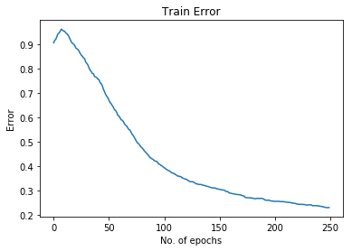

```
Learning Rate: -0.1
Error Rate:- 0.0757238307349666
```

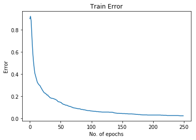

```
Learning Rate: -1
Error Rate:- 0.060133630289532294
```

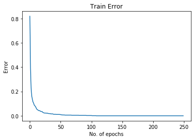

```
Learning Rate: -10
Error Rate:- 0.06904231625835189
```

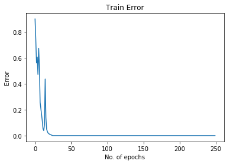

```
Learning Rate: -100
Error Rate:- 0.8997772828507795
```

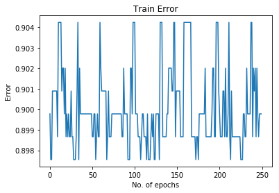

```python
lrs=[.001,.01,.1,1,10,100]
errors=[]
for i in lrs:
    print('Learning Rate: -'+str(i))
    X = np.genfromtxt('DATA/Digit_X_train.csv', delimiter=',')
    y = np.genfromtxt('DATA/Digit_y_train.csv', delimiter=',').astype(np.int64)
    m = X.shape[0]
    input_dim = int(X.shape[1])
    output_dim = int(y.max() + 1)
    nodes = 20
    nn=regularized_nn(input_dim,  nodes , output_dim,alpha=i)
    train_err = nn.fit(X,y,2500)
    X_test = np.genfromtxt('DATA/Digit_X_test.csv', delimiter=',')
    y_test = np.genfromtxt('DATA/Digit_y_test.csv', delimiter=',').astype(np.int64)

    y_pred = nn.predict(X_test)

    error_rate = nn.compute_cost(y_pred,y_test,m)
    errors.append(error_rate)
    print("Error Rate:- "+str(error_rate))
    plt.plot(train_err)
    plt.title('Train Error')
    plt.xlabel('No. of epochs')
    plt.ylabel("Error")
    plt.show()
```

## Learning rate/ Error Plot

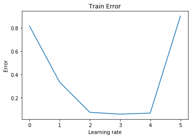

```python
plt.plot(errors)
plt.title('Train Error')
plt.xlabel('Learning rate')
plt.ylabel("Error")
plt.show()
```